# Data Exploration Part 1

# Business Question 1: Does the weather effectively influence the flights departure delays?

```r
library(tidyverse)
library(GGally)
```

```r
tight_flights_weather <- read_csv(here::here("cleaned_data/tight_flights_weather.csv"))
```

```r
skimr::skim(tight_flights_weather)
```

```
── Data Summary ────────────────────────
                           Values
Name                       tight_flights_weather
Number of rows             291851
Number of columns          19
_______________________
Column type frequency:
  character                6
  numeric                  12
  POSIXct                  1
________________________
Group variables            None
```

|  | skim_variable | n_missing | complete_rate | min | max | empty | n_unique | whitespace |
| --- | --- | --- | --- | --- | --- | --- | --- | --- |
| 1 | carrier | 0 | 1 | 2 | 2 | 0 | 12 | 0 |
| 2 | tailnum | 0 | 1 | 5 | 6 | 0 | 4119 | 0 |
| 3 | origin | 0 | 1 | 3 | 3 | 0 | 3 | 0 |
| 4 | dest | 0 | 1 | 3 | 3 | 0 | 109 | 0 |
| 5 | wind_speed_group | 0 | 1 | 5 | 7 | 0 | 4 | 0 |
| 6 | visib_group | 0 | 1 | 5 | 14 | 0 | 4 | 0 |

|  | skim_variable | n_missing | complete_rate | mean | sd | p0 | p25 | p50 | p75 | p100 | hist |
| --- | --- | --- | --- | --- | --- | --- | --- | --- | --- | --- | --- |
| 1 | dep_delay | 0 | 1.0000000 | 15.183751 | 52.141573 | -84.00 | -6.000000 | -2.00000 | 12.00000 | 1548.00000 | ▇▁▁▁▁ |
| 2 | arr_delay | 1031 | 0.9964674 | 7.115446 | 55.427592 | -98.00 | -20.000000 | -7.00000 | 13.00000 | 1589.00000 | ▇▁▁▁▁ |
| 3 | flight | 0 | 1.0000000 | 1688.730541 | 1453.366306 | 1.00 | 518.000000 | 1332.00000 | 2230.00000 | 6988.00000 | ▇▅▁▁▁ |
| 4 | air_time | 1031 | 0.9964674 | 164.427116 | 97.846936 | 20.00 | 99.000000 | 139.00000 | 211.00000 | 712.00000 | ▇▂▂▁▁ |
| 5 | distance | 0 | 1.0000000 | 1161.249360 | 763.318484 | 93.00 | 636.000000 | 1005.00000 | 1598.00000 | 4983.00000 | ▇▃▂▁▁ |
| 6 | wind_dir | 0 | 1.0000000 | 185.578363 | 111.602038 | 0.00 | 75.365854 | 200.00000 | 280.00000 | 360.00000 | ▇▃▆▇▇ |
| 7 | wind_speed | 0 | 1.0000000 | 9.328300 | 4.738362 | 0.00 | 5.753900 | 9.20624 | 12.65858 | 32.22184 | ▅▇▂▁▁ |
| 8 | wind_gust | 0 | 1.0000000 | 10.734821 | 5.452812 | 0.00 | 6.621473 | 10.59436 | 14.56724 | 37.08025 | ▅▇▂▁▁ |
| 9 | visib | 0 | 1.0000000 | 9.371928 | 1.853584 | 0.12 | 10.000000 | 10.00000 | 10.00000 | 10.00000 | ▁▁▁▁▇ |
| 10 | month | 0 | 1.0000000 | 6.549911 | 3.395626 | 1.00 | 4.000000 | 7.00000 | 9.00000 | 12.00000 | ▇▆▆▆▇ |

[output cut: 2 more lines]

|  | skim_variable | n_missing | complete_rate | min | max | median | n_unique |
| --- | --- | --- | --- | --- | --- | --- | --- |
| 1 | time_hour | 0 | 1 | 2017-01-01 08:00:00 | 2017-12-31 07:00:00 | 2017-07-03 11:00:00 | 6757 |

| cor(dep_delay, arr_delay) |
| --- |
| 0.9411317 |

**ASSUMPTION 2** First of all we notice that the arrival delays are strongly positive correlated with the departure delay. Since also the weather dataset refers only to the departure airports and for now I decided to ignore the arrival delays, I could consider to leave the `flights_weather` dataset as it is and to consider a smoller dataset to possibly join with the other that doesn’t contains the departure delays.

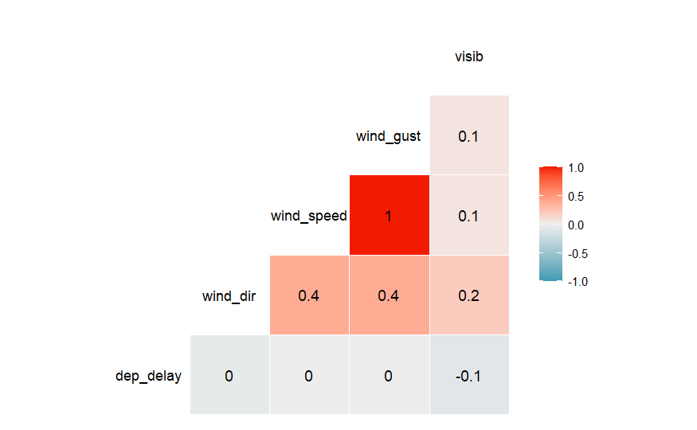

At a first sight, looking at the correlation indexes, it seems that there is not so much interaction between `dep_delays` and `weather` conditions.

I also notice that there is a very strong correlation between `wind speed` and `wind gust speed` for this reason, I could consider to delete one of the two since their relationship is so strong.

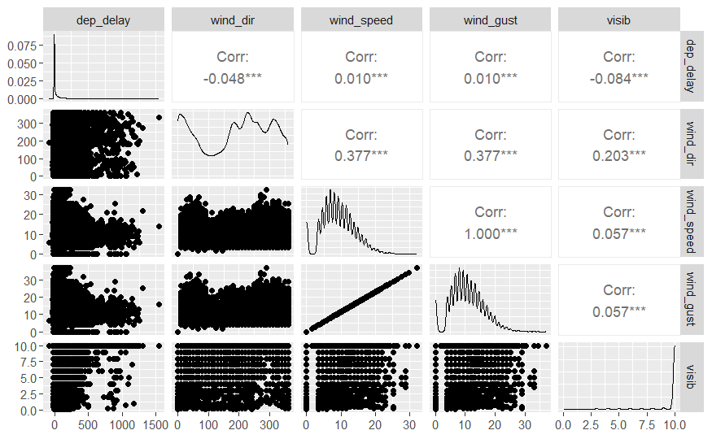

It seems interesting to analyse the relationship that `dep_delays` has with `wind_speed` and `visibility`.

# Wind Speed

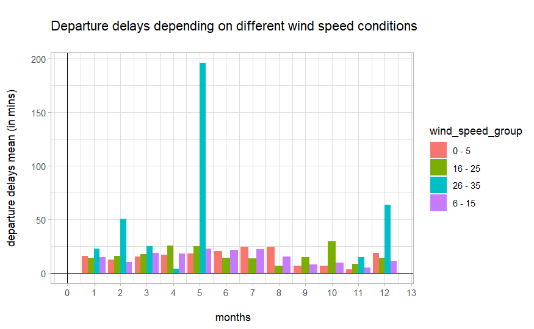

```r
tight_flights_weather %>%
  group_by(month, wind_speed_group) %>%
  summarise(mean_dep_delay = mean(dep_delay, na.rm = TRUE)) %>%
  ggplot()+
  aes(x = month, y = mean_dep_delay, fill = wind_speed_group)+
  geom_col(position = "dodge")+
  #geom_line() +
  geom_vline(xintercept = 0) +
  geom_hline(yintercept = 0) +
  theme_light()+
  labs(
    x = "\n months",
    y = "departure delays mean (in mins)\n",
    title = "\nDeparture delays depending on different wind speed conditions\n"
  )+
  scale_x_continuous(n.breaks = 12)
```

However, looking with more attention at the above plot, we can notice that, at least, month by month it seems that the length of the delays increase when the wind speed is particularly high (look at May) even if even this proportion doesn’t seems to be regular.

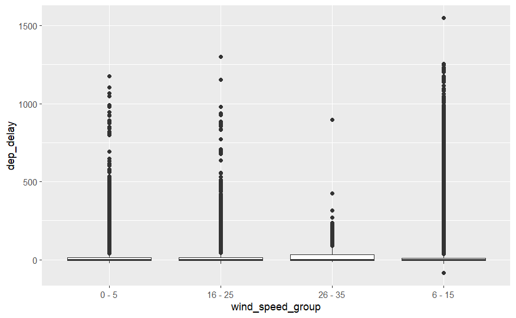

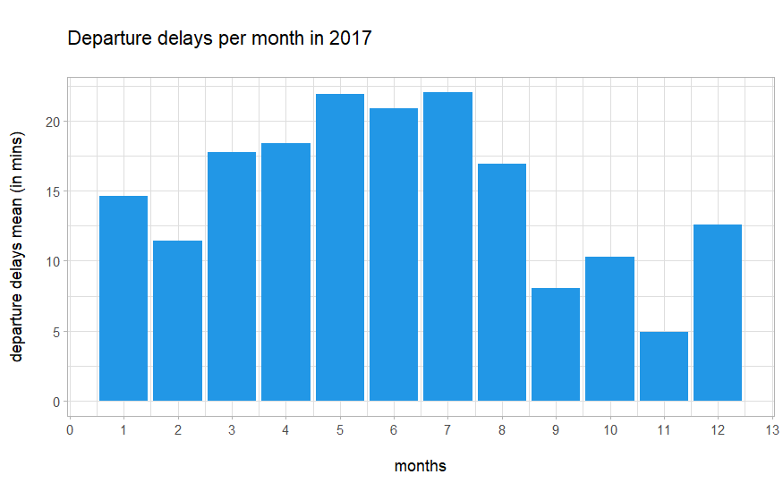

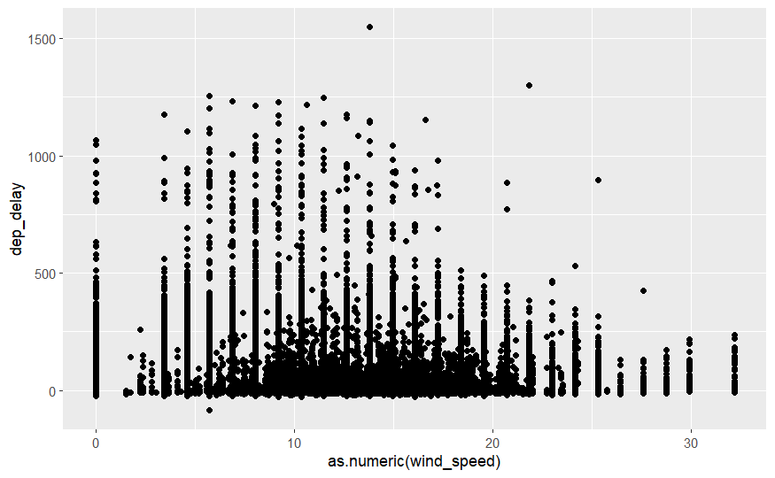

Looking at this plot, it seems that the wind speed influence more the number of delays than their length at least when it is less than 25, this could suggest that for very critical wind speed conditions the planes are equipped to deal with such intence wind!? by this is just an assumption.

## Visib

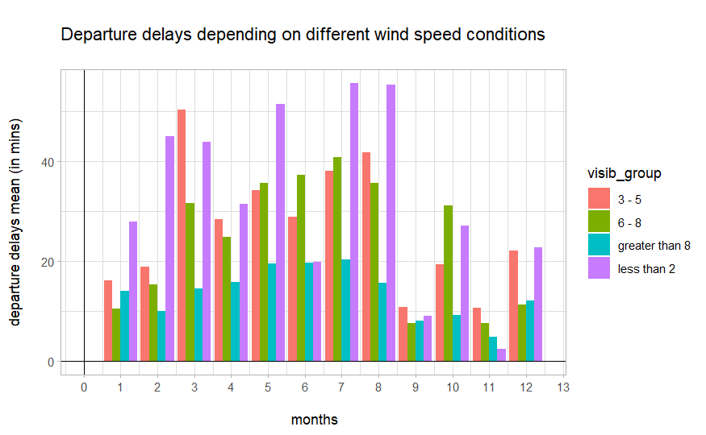

```r
tight_flights_weather %>%
  group_by(month, visib_group) %>%
  summarise(mean_dep_delay = mean(dep_delay, na.rm = TRUE)) %>%
  ggplot()+
  aes(x = month, y = mean_dep_delay, fill = visib_group)+
  geom_col(position = "dodge")+
  #geom_line() +
  geom_vline(xintercept = 0) +
  geom_hline(yintercept = 0) +
  theme_light()+
  labs(
    x = "\n months",
    y = "departure delays mean (in mins)\n",
    title = "\nDeparture delays depending on different wind speed conditions\n"
  )+
  scale_x_continuous(n.breaks = 12)
```

It seems that the visibility can be considered as a better parameter for measuring the departure delays than the wind speed.

However, since we saw that the correlation coefficient is still very low, we can deduce that even if its true that in mean less visibility is in some way proportional to the length of delays it cannot be considered as a significant parameter.

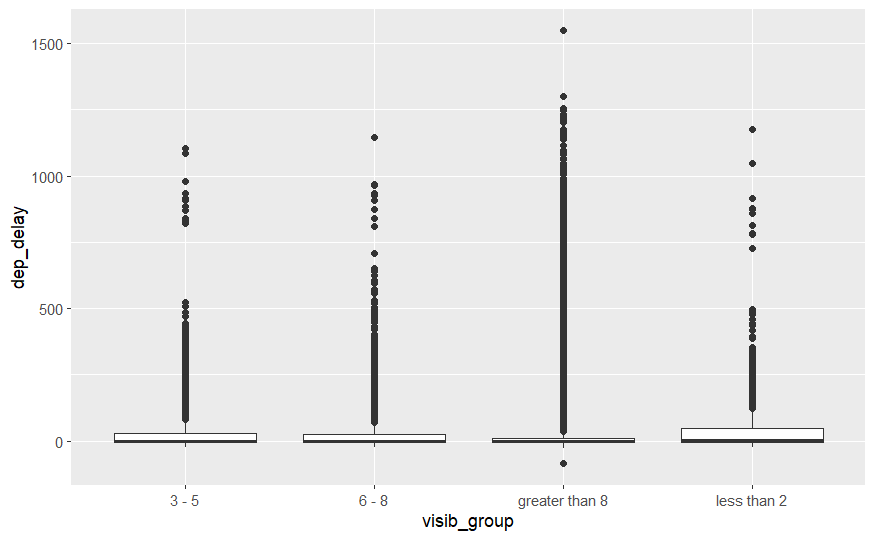

| wind_dir |
| --- |
| 10.00000 |
| 360.00000 |
| 350.00000 |
| 20.00000 |
| 40.00000 |
| 70.00000 |
| 30.00000 |
| 340.00000 |
| 50.00000 |
| 290.00000 |

[output cut: 567 more lines]

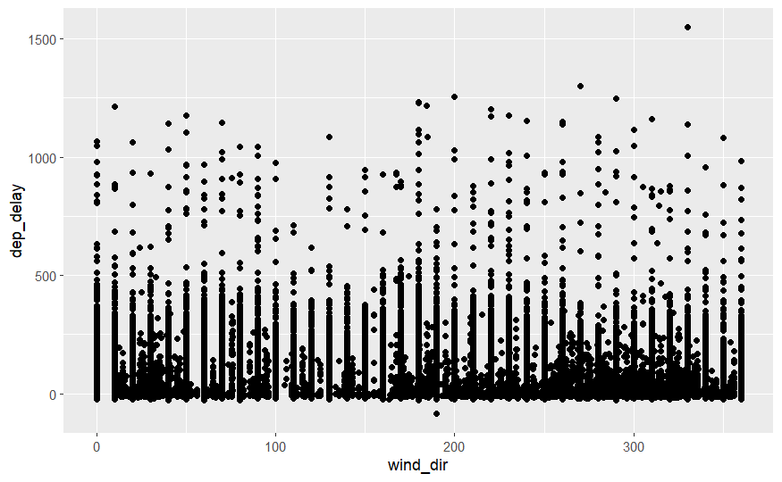

I don’t find from this plot a particular incidence of `wind_dir` with the `dep_delay`.

## Business Question 2:

Are there any other factors that together with `wind speed` and `visibility` influence the length of flights delays?

### Airlines

```r
airlines <- read_csv("../raw_data/airlines.csv") %>%
  rename("airline" = "name")
```

```r
airlines_weather_imp <- left_join(tight_flights_weather, airlines, "carrier")
airlines_weather_imp
```

| dep_delay | arr_delay | carrier | flight | tailnum | origin | dest | air_time | distance | time_hour | wind_dir | wind_speed | wind_gust | visib | month | day | hour | wind_speed_group | visib_group | airline |
| --- | --- | --- | --- | --- | --- | --- | --- | --- | --- | --- | --- | --- | --- | --- | --- | --- | --- | --- | --- |
| 193 | 182 | UA | 1537 | N54711 | EWR | MIA | 148 | 1085 | 2017-10-01 21:00:00 | 10 | 8.05546 | 9.270062 | 10 | 10 | 1 | 21 | 6 - 15 | greater than 8 | United Air Lines Inc. |
| -6 | -18 | UA | 1161 | N37287 | EWR | IAH | 183 | 1400 | 2017-10-01 05:00:00 | 360 | 19.56326 | 22.513008 | 10 | 10 | 1 | 5 | 16 - 25 | greater than 8 | United Air Lines Inc. |
| -1 | -4 | B6 | 27 | N547JB | EWR | MCO | 133 | 937 | 2017-10-01 05:00:00 | 360 | 19.56326 | 22.513008 | 10 | 10 | 1 | 5 | 16 - 25 | greater than 8 | JetBlue Airways |
| -4 | -17 | UA | 761 | N38446 | LGA | ORD | 108 | 733 | 2017-10-01 05:00:00 | 360 | 19.56326 | 22.513008 | 10 | 10 | 1 | 5 | 16 - 25 | greater than 8 | United Air Lines Inc. |
| -8 | -4 | NK | 521 | N675NK | EWR | FLL | 156 | 1065 | 2017-10-01 06:00:00 | 350 | 16.11092 | 18.540125 | 10 | 10 | 1 | 6 | 16 - 25 | greater than 8 | Spirit Air Lines |
| -7 | -6 | B6 | 23 | N967JB | JFK | LAX | 326 | 2475 | 2017-10-01 06:00:00 | 350 | 17.26170 | 19.864419 | 10 | 10 | 1 | 6 | 16 - 25 | greater than 8 | JetBlue Airways |
| -6 | 0 | AA | 129 | N3GMAA | LGA | MCO | 139 | 950 | 2017-10-01 06:00:00 | 350 | 14.96014 | 17.215830 | 10 | 10 | 1 | 6 | 6 - 15 | greater than 8 | American Airlines Inc. |
| -12 | -22 | UA | 1465 | N17229 | EWR | DFW | 187 | 1372 | 2017-10-01 06:00:00 | 350 | 16.11092 | 18.540125 | 10 | 10 | 1 | 6 | 16 - 25 | greater than 8 | United Air Lines Inc. |
| -5 | -21 | AA | 1301 | N3BMAA | EWR | MIA | 143 | 1085 | 2017-10-01 06:00:00 | 350 | 16.11092 | 18.540125 | 10 | 10 | 1 | 6 | 16 - 25 | greater than 8 | American Airlines Inc. |
| -4 | -13 | DL | 575 | N932DL | EWR | ATL | 103 | 746 | 2017-10-01 06:00:00 | 350 | 16.11092 | 18.540125 | 10 | 10 | 1 | 6 | 16 - 25 | greater than 8 | Delta Air Lines Inc. |

[output cut: 990 more lines]

```r
airlines_weather_imp %>%
  summarise(across(.col = everything(), .fns = ~sum(is.na(.x))))
```

| dep_delay | arr_delay | carrier | flight | tailnum | origin | dest | air_time | distance | time_hour | wind_dir | wind_speed | wind_gust | visib | month | day | hour | wind_speed_group | visib_group | airline |
| --- | --- | --- | --- | --- | --- | --- | --- | --- | --- | --- | --- | --- | --- | --- | --- | --- | --- | --- | --- |
| 0 | 1031 | 0 | 0 | 0 | 0 | 0 | 1031 | 0 | 0 | 0 | 0 | 0 | 0 | 0 | 0 | 0 | 0 | 0 | 0 |

| carrier |
| --- |
| UA |
| B6 |
| NK |
| AA |
| DL |
| WN |
| EV |
| AS |
| OO |
| VX |

[output cut: 2 more lines]

First of all let’s have a look to see if there is a particular difference in terms of flights delays length among the different airlines.

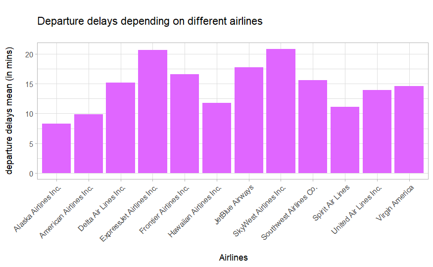

It seems that `ExpressJet Airlines` and `SkyWest Airlines` register the longest delays.

Let’s have a look now at how this is related to the weather.

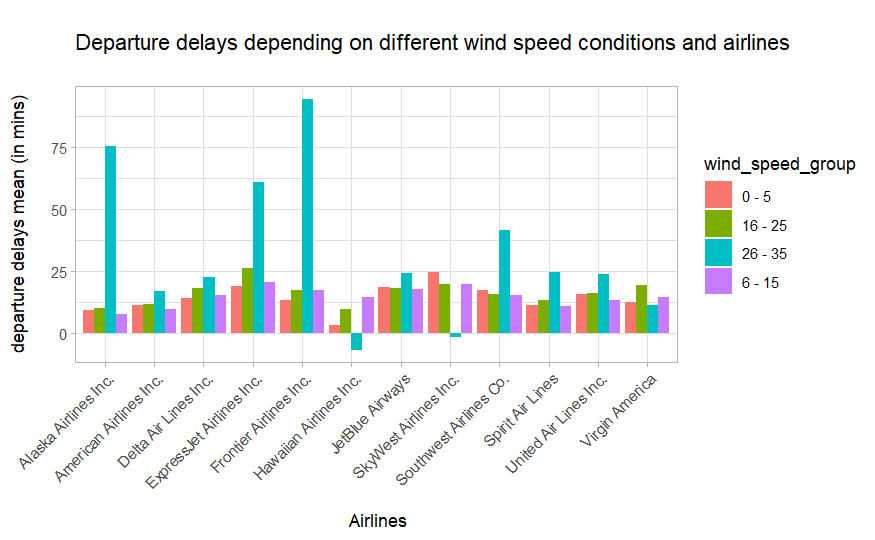

```r
airlines_weather_imp %>%
  group_by(airline, wind_speed_group) %>%
  summarise(mean_dep_delay = mean(dep_delay, na.rm = TRUE)) %>%
  ggplot()+
  aes(x = airline, y = mean_dep_delay, fill = wind_speed_group)+
  geom_col(position = "dodge")+
  theme_light()+
  labs(
    x = "\n Airlines",
    y = "departure delays mean (in mins)\n",
    title = "\nDeparture delays depending on different wind speed conditions and airlines\n"
  )+
  scale_x_discrete(guide = guide_axis(angle = 45))
```

Comparing these two last plots I can conclude that on the one hand, very fast winds can be related to longer delays, but it still doesn’t seem to be the major impact factor. It seems that the impact that wind speed can have on the length of the delays depends, in addition to the period of the year, also from an airline to the other. Let’s have a look, for example, at the `Alaska Airlines`. In mean it register the shortest delays with respect to the other companies, even if it seems that the length of delays for this company is strongly related to the wind speed. An opposite conclusion instead can be drawn, for example, for the `SkyWest Airlines` which seems to register longer delays which doesn’t seems to be very much related to the wind speed.

[output not shown]

[output cut: 990 more lines]

## Airports

```r
airports_weather_imp <- read_csv("../cleaned_data/airports_weather_imp.csv")
```

| dep_delay | arr_delay | carrier | flight | tailnum | origin | dest | air_time | distance | time_hour | wind_dir | wind_speed | wind_gust | visib | month | day | hour | wind_speed_group | visib_group | airport | lat | lon | alt | tz | dst | tzone |
| --- | --- | --- | --- | --- | --- | --- | --- | --- | --- | --- | --- | --- | --- | --- | --- | --- | --- | --- | --- | --- | --- | --- | --- | --- | --- |
| 193 | 182 | UA | 1537 | N54711 | EWR | MIA | 148 | 1085 | 2017-10-01 21:00:00 | 10 | 8.05546 | 9.270062 | 10 | 10 | 1 | 21 | 6 - 15 | greater than 8 | Newark Liberty International Airport | 40.6925 | -74.1687 | 18 | -5 | A | America/New_York |
| -6 | -18 | UA | 1161 | N37287 | EWR | IAH | 183 | 1400 | 2017-10-01 05:00:00 | 360 | 19.56326 | 22.513008 | 10 | 10 | 1 | 5 | 16 - 25 | greater than 8 | Newark Liberty International Airport | 40.6925 | -74.1687 | 18 | -5 | A | America/New_York |
| -1 | -4 | B6 | 27 | N547JB | EWR | MCO | 133 | 937 | 2017-10-01 05:00:00 | 360 | 19.56326 | 22.513008 | 10 | 10 | 1 | 5 | 16 - 25 | greater than 8 | Newark Liberty International Airport | 40.6925 | -74.1687 | 18 | -5 | A | America/New_York |
| -4 | -17 | UA | 761 | N38446 | LGA | ORD | 108 | 733 | 2017-10-01 05:00:00 | 360 | 19.56326 | 22.513008 | 10 | 10 | 1 | 5 | 16 - 25 | greater than 8 | La Guardia Airport | 40.7772 | -73.8726 | 21 | -5 | A | America/New_York |
| -8 | -4 | NK | 521 | N675NK | EWR | FLL | 156 | 1065 | 2017-10-01 06:00:00 | 350 | 16.11092 | 18.540125 | 10 | 10 | 1 | 6 | 16 - 25 | greater than 8 | Newark Liberty International Airport | 40.6925 | -74.1687 | 18 | -5 | A | America/New_York |
| -7 | -6 | B6 | 23 | N967JB | JFK | LAX | 326 | 2475 | 2017-10-01 06:00:00 | 350 | 17.26170 | 19.864419 | 10 | 10 | 1 | 6 | 16 - 25 | greater than 8 | John F Kennedy International Airport | 40.6398 | -73.7789 | 13 | -5 | A | America/New_York |
| -6 | 0 | AA | 129 | N3GMAA | LGA | MCO | 139 | 950 | 2017-10-01 06:00:00 | 350 | 14.96014 | 17.215830 | 10 | 10 | 1 | 6 | 6 - 15 | greater than 8 | La Guardia Airport | 40.7772 | -73.8726 | 21 | -5 | A | America/New_York |
| -12 | -22 | UA | 1465 | N17229 | EWR | DFW | 187 | 1372 | 2017-10-01 06:00:00 | 350 | 16.11092 | 18.540125 | 10 | 10 | 1 | 6 | 16 - 25 | greater than 8 | Newark Liberty International Airport | 40.6925 | -74.1687 | 18 | -5 | A | America/New_York |
| -5 | -21 | AA | 1301 | N3BMAA | EWR | MIA | 143 | 1085 | 2017-10-01 06:00:00 | 350 | 16.11092 | 18.540125 | 10 | 10 | 1 | 6 | 16 - 25 | greater than 8 | Newark Liberty International Airport | 40.6925 | -74.1687 | 18 | -5 | A | America/New_York |
| -4 | -13 | DL | 575 | N932DL | EWR | ATL | 103 | 746 | 2017-10-01 06:00:00 | 350 | 16.11092 | 18.540125 | 10 | 10 | 1 | 6 | 16 - 25 | greater than 8 | Newark Liberty International Airport | 40.6925 | -74.1687 | 18 | -5 | A | America/New_York |

[output cut: 990 more lines]

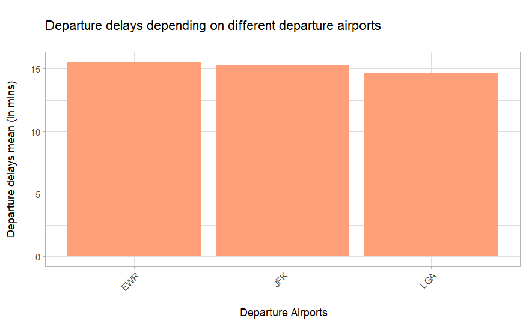

It doesn’t seems that airports doesn’t have a particular incidence with the length of delays, but let’s have a look of the different weather conditions.

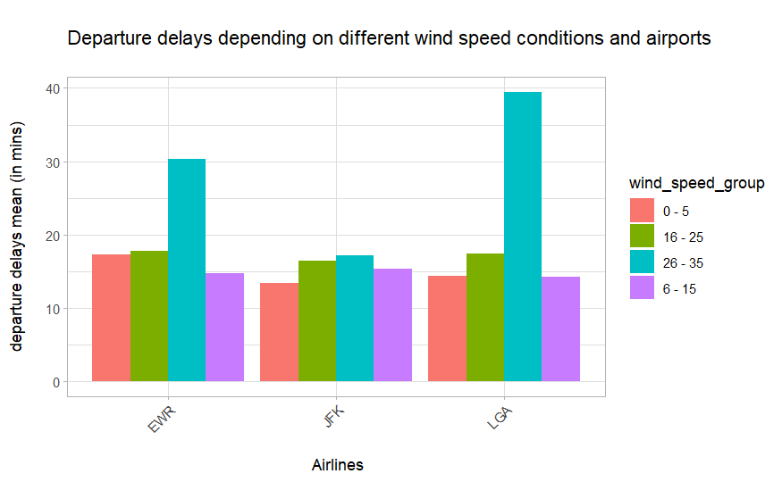

```r
airlines_weather_imp %>%
  group_by(origin, wind_speed_group) %>%
  summarise(mean_dep_delay = mean(dep_delay, na.rm = TRUE)) %>%
  ggplot()+
  aes(x = origin, y = mean_dep_delay, fill = wind_speed_group)+
  geom_col(position = "dodge")+
  theme_light()+
  labs(
    x = "\n Airlines",
    y = "departure delays mean (in mins)\n",
    title = "\nDeparture delays depending on different wind speed conditions and airports\n"
  )+
  scale_x_discrete(guide = guide_axis(angle = 45))
```

It seems that a very intense wind speed influence in some ways the length of flights delays in the airports of `La Guardia`, so as in `Newark Liberty`, which is the one we are more interested in. Less impact instead seems to have at `JFK`. However, just winds with a speed greater than 26 mph seems to have any kind of relationship, there is no significant patterns to find out for winds with a less intense speed than 26.

| airport | origin |
| --- | --- |
| Newark Liberty International Airport | EWR |
| La Guardia Airport | LGA |
| John F Kennedy International Airport | JFK |

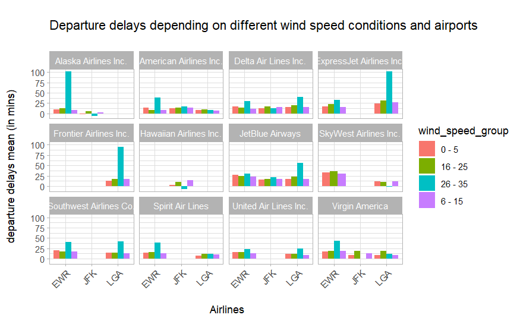

```r
airlines_weather_imp %>%
  group_by(origin, airline, wind_speed_group) %>%
  summarise(mean_dep_delay = mean(dep_delay, na.rm = TRUE)) %>%
  ggplot()+
  aes(x = origin, y = mean_dep_delay, fill = wind_speed_group)+
  geom_col(position = "dodge")+
  theme_light()+
  labs(
    x = "\n Airlines",
    y = "departure delays mean (in mins)\n",
    title = "\nDeparture delays depending on different wind speed conditions and airports\n"
  )+
  scale_x_discrete(guide = guide_axis(angle = 45))+
  facet_wrap(~airline)
```

Very few companies seems to have a certain relationship between very intence wind speed and length of delays and only in specific airports.

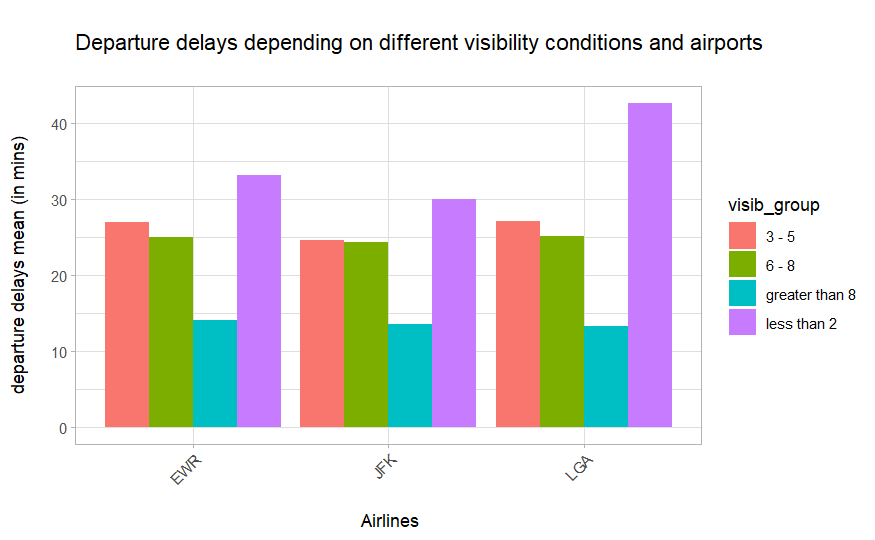

```r
airlines_weather_imp %>%
  group_by(origin, visib_group) %>%
  summarise(mean_dep_delay = mean(dep_delay, na.rm = TRUE)) %>%
  ggplot()+
  aes(x = origin, y = mean_dep_delay, fill = visib_group)+
  geom_col(position = "dodge")+
  theme_light()+
  labs(
    x = "\n Airlines",
    y = "departure delays mean (in mins)\n",
    title = "\nDeparture delays depending on different visibility conditions and airports\n"
  )+
  scale_x_discrete(guide = guide_axis(angle = 45))
```

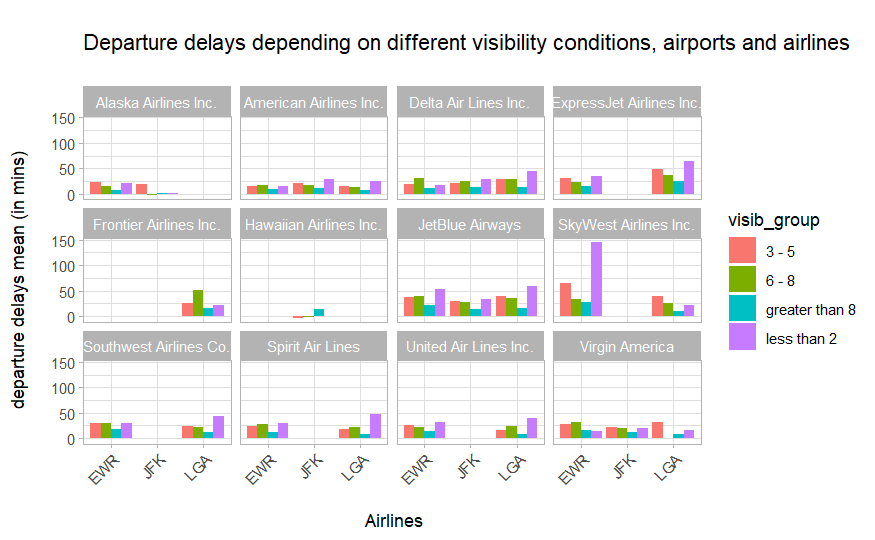

```r
airlines_weather_imp %>%
  group_by(origin, airline, visib_group) %>%
  summarise(mean_dep_delay = mean(dep_delay, na.rm = TRUE)) %>%
  ggplot()+
  aes(x = origin, y = mean_dep_delay, fill = visib_group)+
  geom_col(position = "dodge")+
  theme_light()+
  labs(
    x = "\n Airlines",
    y = "departure delays mean (in mins)\n",
    title = "\nDeparture delays depending on different visibility conditions, airports and airlines\n"
  )+
  scale_x_discrete(guide = guide_axis(angle = 45))+
  facet_wrap(~airline)
```

Just `SkyWest Airlines` at `Nework Liberty International Airport` seems to have a strong relation between delays’ length and very low visibility.